# Exercise 5. Analysis of longitudinal data

Load some libraries

```r
library(dplyr)
```

```r
library(ggplot2)
library(GGally)
library(tidyr)
```

First load the wrangled (longitudinal = L) datasets and original datasets into R

```r
BPRSL <- read.table("C:/Users/JT/Documents/IODS/IODS-project/data/BPRSL.txt",
                 sep = ",",
                 header = TRUE
                 )

RATSL <- read.table("C:/Users/JT/Documents/IODS/IODS-project/data/RATSL.txt",
                 sep = ",",
                 header = TRUE
                 )

BPRS <- read.table("https://raw.githubusercontent.com/KimmoVehkalahti/MABS/master/Examples/data/BPRS.txt",
                    sep = "",
                    header = TRUE
)

RATS <- read.table("https://raw.githubusercontent.com/KimmoVehkalahti/MABS/master/Examples/data/rats.txt",
                   sep = "\t",
                   header = TRUE
)
```

The RATSL dataset is from a rat nutrition study by Crowder and Hand (1990), in which three groups of rats were put on diﬀerent diets, and each animal’s body weight (grams) was recorded repeatedly (approximately weekly, except in week seven when two recordings were taken) over a 9-week period.

The BPRSL dataset is from Davis (2002). In the experiment 40 male subjects were randomly assigned to one of two treatment groups and each subject was rated on the brief psychiatric rating scale (BPRS) measured before treatment be- gan (week 0) and then at weekly intervals for eight weeks. The BPRS assesses the level of 18 symptom constructs such as hostility, suspiciousness, halluci- nations and grandiosity; each of these is rated from one (not present) to seven (extremely severe). The scale is used to evaluate patients suspected of having schizophrenia.

## Prepare the datasets

Now, let’s check the data

```r
#The BPRSL dataset
names(BPRSL)
```

```
## [1] "treatment" "subject"   "weeks"     "bprs"      "week"
```

```r
str(BPRSL)
```

```
## 'data.frame':    360 obs. of  5 variables:
##  $ treatment: int  1 1 1 1 1 1 1 1 1 1 ...
##  $ subject  : int  1 2 3 4 5 6 7 8 9 10 ...
##  $ weeks    : chr  "week0" "week0" "week0" "week0" ...
##  $ bprs     : int  42 58 54 55 72 48 71 30 41 57 ...
##  $ week     : int  0 0 0 0 0 0 0 0 0 0 ...
```

```r
summary(BPRSL)
```

```
##    treatment      subject         weeks                bprs            week
##  Min.   :1.0   Min.   : 1.00   Length:360         Min.   :18.00   Min.   :0
##  1st Qu.:1.0   1st Qu.: 5.75   Class :character   1st Qu.:27.00   1st Qu.:2
##  Median :1.5   Median :10.50   Mode  :character   Median :35.00   Median :4
##  Mean   :1.5   Mean   :10.50                      Mean   :37.66   Mean   :4
##  3rd Qu.:2.0   3rd Qu.:15.25                      3rd Qu.:43.00   3rd Qu.:6
##  Max.   :2.0   Max.   :20.00                      Max.   :95.00   Max.   :8
```

```r
glimpse(BPRSL)
```

```
## Rows: 360
## Columns: 5
## $ treatment <int> 1, 1, 1, 1, 1, 1, 1, 1, 1, 1, 1, 1, 1, 1, 1, 1, 1, 1, 1, ...
## $ subject   <int> 1, 2, 3, 4, 5, 6, 7, 8, 9, 10, 11, 12, 13, 14, 15, 16, 17...
## $ weeks     <chr> "week0", "week0", "week0", "week0", "week0", "week0", "we...
## $ bprs      <int> 42, 58, 54, 55, 72, 48, 71, 30, 41, 57, 30, 55, 36, 38, 6...
## $ week      <int> 0, 0, 0, 0, 0, 0, 0, 0, 0, 0, 0, 0, 0, 0, 0, 0, 0, 0, 0, ...
```

```r
#The RATSL dataset
names(RATSL)
```

```
## [1] "ID"     "Group"  "WD"     "Weight" "Time"
```

```r
str(RATSL)
```

```
## 'data.frame':    176 obs. of  5 variables:
##  $ ID    : int  1 2 3 4 5 6 7 8 9 10 ...
##  $ Group : int  1 1 1 1 1 1 1 1 2 2 ...
##  $ WD    : chr  "WD1" "WD1" "WD1" "WD1" ...
##  $ Weight: int  240 225 245 260 255 260 275 245 410 405 ...
##  $ Time  : int  1 1 1 1 1 1 1 1 1 1 ...
```

```r
summary(RATSL)
```

```
##        ID            Group           WD                Weight
##  Min.   : 1.00   Min.   :1.00   Length:176         Min.   :225.0
##  1st Qu.: 4.75   1st Qu.:1.00   Class :character   1st Qu.:267.0
##  Median : 8.50   Median :1.50   Mode  :character   Median :344.5
##  Mean   : 8.50   Mean   :1.75                      Mean   :384.5
##  3rd Qu.:12.25   3rd Qu.:2.25                      3rd Qu.:511.2
##  Max.   :16.00   Max.   :3.00                      Max.   :628.0
##       Time
##  Min.   : 1.00
##  1st Qu.:15.00
##  Median :36.00
##  Mean   :33.55
##  3rd Qu.:50.00
##  Max.   :64.00
```

```r
glimpse(RATSL)
```

```
## Rows: 176
## Columns: 5
## $ ID     <int> 1, 2, 3, 4, 5, 6, 7, 8, 9, 10, 11, 12, 13, 14, 15, 16, 1, 2,...
## $ Group  <int> 1, 1, 1, 1, 1, 1, 1, 1, 2, 2, 2, 2, 3, 3, 3, 3, 1, 1, 1, 1, ...
## $ WD     <chr> "WD1", "WD1", "WD1", "WD1", "WD1", "WD1", "WD1", "WD1", "WD1...
## $ Weight <int> 240, 225, 245, 260, 255, 260, 275, 245, 410, 405, 445, 555, ...
## $ Time   <int> 1, 1, 1, 1, 1, 1, 1, 1, 1, 1, 1, 1, 1, 1, 1, 1, 8, 8, 8, 8, ...
```

As it was observed that R did not load the factorized (categorial) variables correctly, it is necessary to re-factorize them

```r
BPRSL$treatment <- factor(BPRSL$treatment)
BPRSL$subject <- factor(BPRSL$subject)

RATSL$ID <- factor(RATSL$ID)
RATSL$Group <- factor(RATSL$Group)
```

Ensure that the datasets looks as it should:

```r
glimpse(BPRSL)
```

```
## Rows: 360
## Columns: 5
## $ treatment <fct> 1, 1, 1, 1, 1, 1, 1, 1, 1, 1, 1, 1, 1, 1, 1, 1, 1, 1, 1, ...
## $ subject   <fct> 1, 2, 3, 4, 5, 6, 7, 8, 9, 10, 11, 12, 13, 14, 15, 16, 17...
## $ weeks     <chr> "week0", "week0", "week0", "week0", "week0", "week0", "we...
## $ bprs      <int> 42, 58, 54, 55, 72, 48, 71, 30, 41, 57, 30, 55, 36, 38, 6...
## $ week      <int> 0, 0, 0, 0, 0, 0, 0, 0, 0, 0, 0, 0, 0, 0, 0, 0, 0, 0, 0, ...
```

```r
glimpse(RATSL)
```

```
## Rows: 176
## Columns: 5
## $ ID     <fct> 1, 2, 3, 4, 5, 6, 7, 8, 9, 10, 11, 12, 13, 14, 15, 16, 1, 2,...
## $ Group  <fct> 1, 1, 1, 1, 1, 1, 1, 1, 2, 2, 2, 2, 3, 3, 3, 3, 1, 1, 1, 1, ...
## $ WD     <chr> "WD1", "WD1", "WD1", "WD1", "WD1", "WD1", "WD1", "WD1", "WD1...
## $ Weight <int> 240, 225, 245, 260, 255, 260, 275, 245, 410, 405, 445, 555, ...
## $ Time   <int> 1, 1, 1, 1, 1, 1, 1, 1, 1, 1, 1, 1, 1, 1, 1, 1, 8, 8, 8, 8, ...
```

## Task 1: Implement the analyses of Chapter 8 of MABS using the RATS data

To start let’s plot the raw data

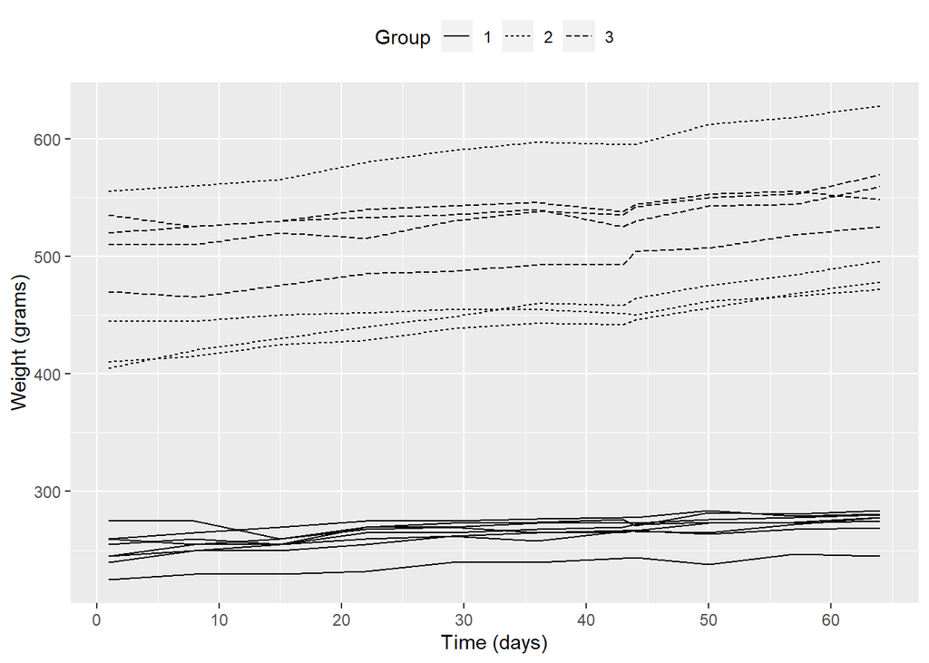

```r
ggplot(RATSL, aes(x = Time, y = Weight, group = ID)) +
  geom_line(aes(linetype = Group))+scale_x_continuous(name = "Time (days)", breaks = seq(0, 60, 10))+scale_y_continuous(name = "Weight (grams)")+theme(legend.position = "top")
```

There are some clearly noticeable and systematic differences between the weights the rats in the different groups that are fed differently.

Now we plot mean response profiles for weight data the three groups of rats to inspect the behaviour of the mean weights

```r
# Number of days (Time), baseline (Time = 0) included
n <- RATSL$Time %>% unique() %>% length()

# Summary data with mean and standard error of RATSL by Group and Time
RATSS <- RATSL %>%
  group_by(Group, Time) %>%
  summarise( mean = mean(Weight), se = sd(Weight)/sqrt(n)) %>%
  ungroup()
# Glimpse the data
glimpse(RATSS)
```

```
## Rows: 33
## Columns: 4
## $ Group <fct> 1, 1, 1, 1, 1, 1, 1, 1, 1, 1, 1, 2, 2, 2, 2, 2, 2, 2, 2, 2, 2...
## $ Time  <int> 1, 8, 15, 22, 29, 36, 43, 44, 50, 57, 64, 1, 8, 15, 22, 29, 3...
## $ mean  <dbl> 250.625, 255.000, 254.375, 261.875, 264.625, 265.000, 267.375...
## $ se    <dbl> 4.589478, 3.947710, 3.460116, 4.100800, 3.333956, 3.552939, 3...
```

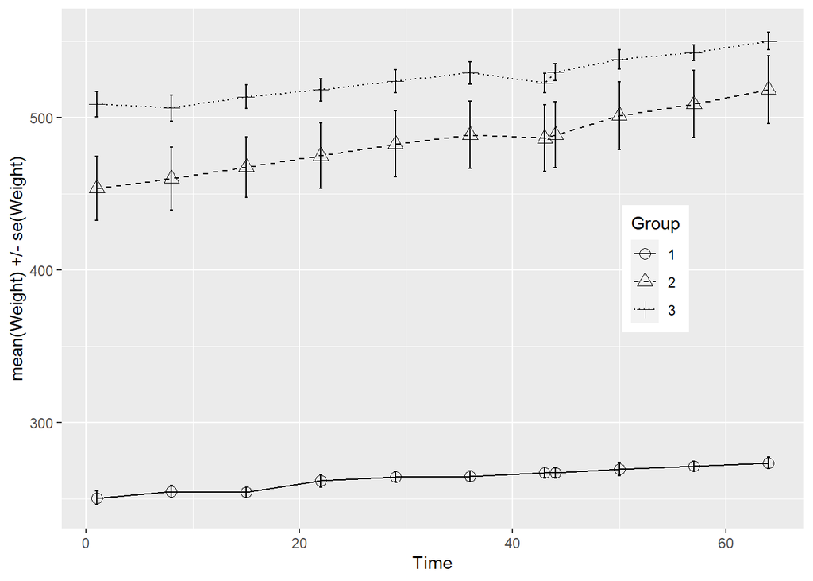

```r
# Plot the mean profiles
ggplot(RATSS, aes(x = Time, y = mean, linetype = Group, shape = Group)) +
  geom_line() +
  scale_linetype_manual(values = c(1,2,3)) +
  geom_point(size=3) +
  scale_shape_manual(values = c(1,2,3)) +
  geom_errorbar(aes(ymin=mean-se, ymax=mean+se, linetype="1"), width=0.3) +
  theme(legend.position = c(0.8,0.5)) +
  scale_y_continuous(name = "mean(Weight) +/- se(Weight)")
```

All mean weights of the groups (1-3) increased with time. Group 2 seemingly grew with the fastest rate. There was clearly more deviation within groups 2 and group 3 than within group 1. The groups differ from each other with at least one standard error at all time. I.e. there is clear difference between the groups

```r
# Create a summary data by Group and ID with mean as the summary variable (ignoring baseline i.e. Time 0).
RATSL8S <- RATSL %>%
  filter(Time > 0) %>%
  group_by(Group, ID) %>%
  summarise( mean=mean(Weight) ) %>%
  ungroup()
# Glimpse the data
glimpse(RATSL8S)
```

```
## Rows: 16
## Columns: 3
## $ Group <fct> 1, 1, 1, 1, 1, 1, 1, 1, 2, 2, 2, 2, 3, 3, 3, 3
## $ ID    <fct> 1, 2, 3, 4, 5, 6, 7, 8, 9, 10, 11, 12, 13, 14, 15, 16
## $ mean  <dbl> 261.0909, 237.6364, 260.1818, 266.5455, 269.4545, 274.7273, 2...
```

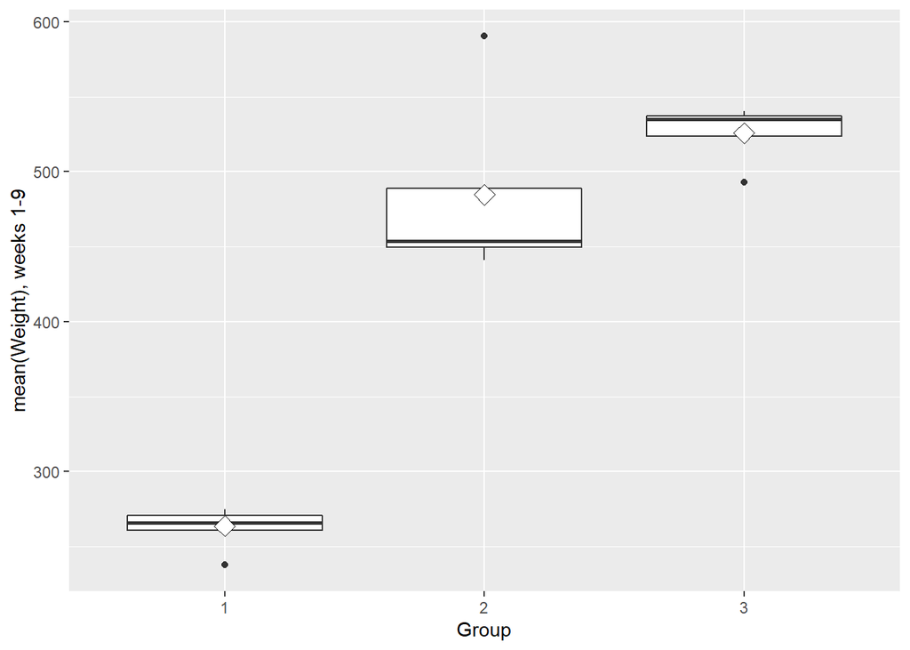

```r
# Draw a boxplot
ggplot(RATSL8S, aes(x = Group, y = mean)) +
  geom_boxplot() +
  stat_summary(fun.y = "mean", geom = "point", shape=23, size=4, fill = "white") +
  scale_y_continuous(name = "mean(Weight), weeks 1-9")
```

As interpreted earlier group 1 has smaller mean weight than group 2 and group 3. The difference between group 2 and group 3 is smaller, but also clear.

The plot revealed some outliers (Weight < 250 g and weight > 550g). Let’s filter theses out and re-draw the boxplot.

```r
# Filter the data
RATSL8S1 <- RATSL8S %>% filter(mean > 250 & mean < 550)


glimpse(RATSL8S1)
```

```
## Rows: 14
## Columns: 3
## $ Group <fct> 1, 1, 1, 1, 1, 1, 1, 2, 2, 2, 3, 3, 3, 3
## $ ID    <fct> 1, 3, 4, 5, 6, 7, 8, 9, 10, 11, 13, 14, 15, 16
## $ mean  <dbl> 261.0909, 260.1818, 266.5455, 269.4545, 274.7273, 274.6364, 2...
```

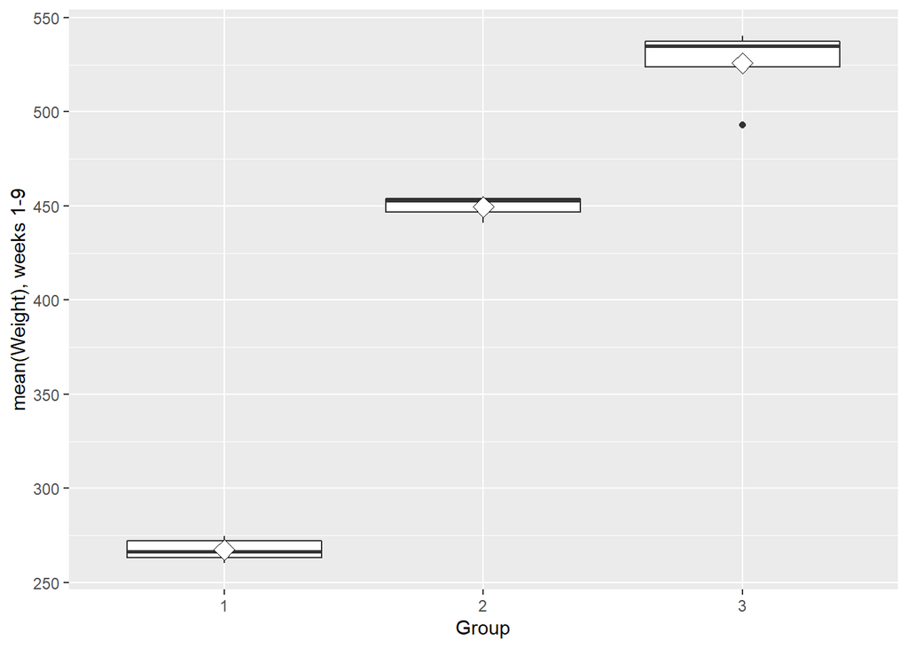

```r
# Draw the boxplot
ggplot(RATSL8S1, aes(x = Group, y = mean)) +
  geom_boxplot() +
  stat_summary(fun.y = "mean", geom = "point", shape=23, size=4, fill = "white") +
  scale_y_continuous(name = "mean(Weight), weeks 1-9")
```

Removing the outlier makes the differences between the groups even more evident.

```r
# Between groups 1 and 2
t.test(mean ~ Group, data = filter(RATSL8S1, Group %in% c(1, 2)), var.equal=TRUE)
```

```
##
##  Two Sample t-test
##
## data:  mean by Group
## t = -41.656, df = 8, p-value = 1.215e-10
## alternative hypothesis: true difference in means is not equal to 0
## 95 percent confidence interval:
##  -192.089 -171.937
## sample estimates:
## mean in group 1 mean in group 2
##        267.4416        449.4545
```

```r
# Between groups 2 and 3
t.test(mean ~ Group, data = filter(RATSL8S1, Group %in% c(2, 3)), var.equal=TRUE)
```

```
##
##  Two Sample t-test
##
## data:  mean by Group
## t = -5.6287, df = 5, p-value = 0.002452
## alternative hypothesis: true difference in means is not equal to 0
## 95 percent confidence interval:
##  -111.20490  -41.47691
## sample estimates:
## mean in group 2 mean in group 3
##        449.4545        525.7955
```

```r
# Between groups 1 and 3
t.test(mean ~ Group, data = filter(RATSL8S1, Group %in% c(1, 3)), var.equal=FALSE)
```

```
##
##  Welch Two Sample t-test
##
## data:  mean by Group
## t = -22.943, df = 3.2445, p-value = 0.0001058
## alternative hypothesis: true difference in means is not equal to 0
## 95 percent confidence interval:
##  -292.7105 -223.9973
## sample estimates:
## mean in group 1 mean in group 3
##        267.4416        525.7955
```

The t-test result tables reveal that the mean weights of the groups differ from each other statistically significantly (p<0.05).

Finally the analysis of variance is. For purpose the baseline is added

```r
# Add the baseline from the original data as a new variable to the summary data
RATSL8S2 <- RATSL8S %>% mutate(baseline =  RATS$WD1)

# Fit the linear model with the mean as the response
fit <- lm(mean ~ baseline + Group, data=RATSL8S2)

# Compute the analysis of variance table for the fitted model with anova()
anova(fit)
```

```
## Analysis of Variance Table
##
## Response: mean
##           Df Sum Sq Mean Sq   F value    Pr(>F)
## baseline   1 252125  252125 2237.0655 5.217e-15 ***
## Group      2    726     363    3.2219   0.07586 .
## Residuals 12   1352     113
## ---
## Signif. codes:  0 '***' 0.001 '**' 0.01 '*' 0.05 '.' 0.1 ' ' 1
```

The anova summary reveals that the baseline weight relates stronlgy to the weights recorded after following the group specific diet. THere are no cler statistical significance with other variables.

## Task 2: Implement the analyses of Chapter 9 of MABS using the BPRS data

First the data is plotted

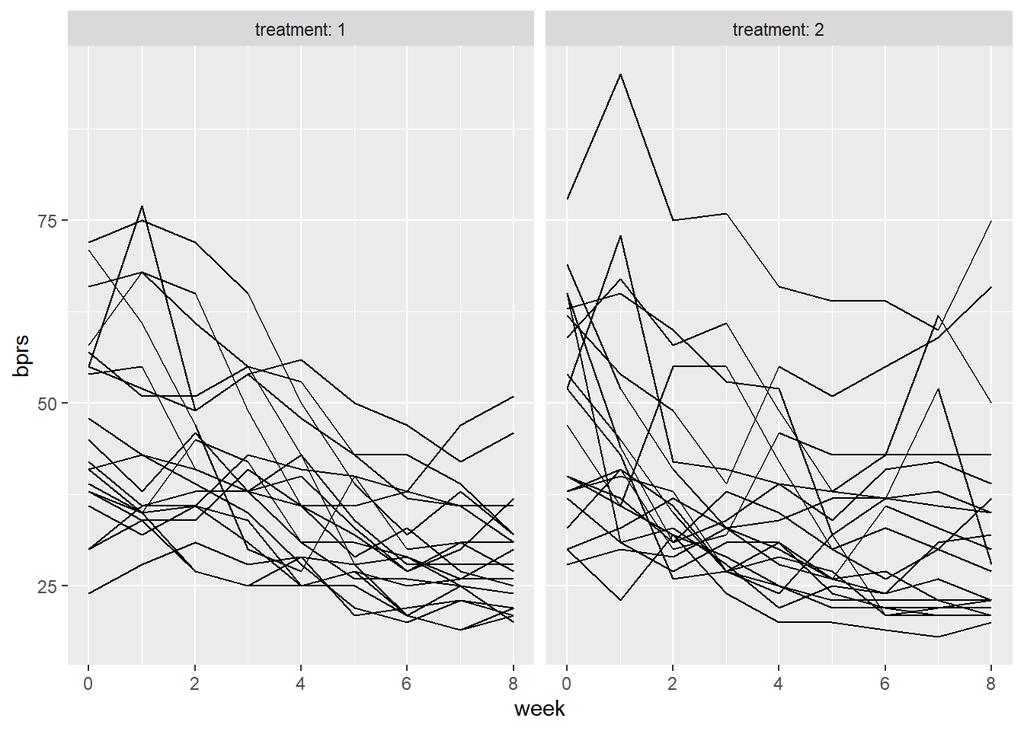

```r
# Plot the RATSL data
# Draw the plot
ggplot(BPRSL, aes(x = week, y = bprs, group = subject)) +
  geom_line() +
  scale_linetype_manual(values = rep(1:10, times=4)) +
  facet_grid(. ~ treatment, labeller = label_both) +
  theme(legend.position = "none") +
  scale_y_continuous(limits = c(min(BPRSL$bprs), max(BPRSL$bprs)))
```

The above figure displays the behaviour of bprs of two treatments over time. On average bprs seemingly decreases over time. for both treatments.

Next a linear regression model is created

```r
# create a regression model RATS_reg
BPRS_reg <- lm(bprs ~ treatment + week, data = BPRSL)

# And print the summary of the model
summary(BPRS_reg)
```

```
##
## Call:
## lm(formula = bprs ~ treatment + week, data = BPRSL)
##
## Residuals:
##     Min      1Q  Median      3Q     Max
## -22.454  -8.965  -3.196   7.002  50.244
##
## Coefficients:
##             Estimate Std. Error t value Pr(>|t|)
## (Intercept)  46.4539     1.3670  33.982   <2e-16 ***
## treatment2    0.5722     1.3034   0.439    0.661
## week         -2.2704     0.2524  -8.995   <2e-16 ***
## ---
## Signif. codes:  0 '***' 0.001 '**' 0.01 '*' 0.05 '.' 0.1 ' ' 1
##
## Residual standard error: 12.37 on 357 degrees of freedom
## Multiple R-squared:  0.1851, Adjusted R-squared:  0.1806
## F-statistic: 40.55 on 2 and 357 DF,  p-value: < 2.2e-16
```

The t-test part in the summary reveals that there is statistically significant relationship between the variable week (time) and the response variable bprs. Significant relationship between the treatment variable and bprs does not exist.

Now, we will create a random intercept model to the data

```r
# access library lme4 necessary here
library(lme4)
# Create a random intercept model
BPRS_ref <- lmer(bprs ~ week + treatment + (1 | subject), data = BPRSL, REML = FALSE)
# Print the summary of the model
summary(BPRS_ref)
```

```
## Linear mixed model fit by maximum likelihood  ['lmerMod']
## Formula: bprs ~ week + treatment + (1 | subject)
##    Data: BPRSL
##
##      AIC      BIC   logLik deviance df.resid
##   2748.7   2768.1  -1369.4   2738.7      355
##
## Scaled residuals:
##     Min      1Q  Median      3Q     Max
## -3.0481 -0.6749 -0.1361  0.4813  3.4855
##
## Random effects:
##  Groups   Name        Variance Std.Dev.
##  subject  (Intercept)  47.41    6.885
##  Residual             104.21   10.208
## Number of obs: 360, groups:  subject, 20
##
## Fixed effects:
##             Estimate Std. Error t value
## (Intercept)  46.4539     1.9090  24.334
## week         -2.2704     0.2084 -10.896
## treatment2    0.5722     1.0761   0.532
##
## Correlation of Fixed Effects:
##            (Intr) week
## week       -0.437
## treatment2 -0.282  0.000
```

From the summary one can interpret that the t-value for treatment2 is very small, which indicates there is no statistically significant difference in the intercepts for observations with different treatments. The week variable has large negative t-value which indicates that the response variable decreases as week increases.

Next, create a random intercept and random slope model

```r
# create a random intercept and random slope model
BPRS_ref1 <- lmer(bprs ~ week + treatment + (week | subject), data = BPRSL, REML = FALSE)

# Print the summary of the model
summary(BPRS_ref1)
```

```
## Linear mixed model fit by maximum likelihood  ['lmerMod']
## Formula: bprs ~ week + treatment + (week | subject)
##    Data: BPRSL
##
##      AIC      BIC   logLik deviance df.resid
##   2745.4   2772.6  -1365.7   2731.4      353
##
## Scaled residuals:
##     Min      1Q  Median      3Q     Max
## -2.8919 -0.6194 -0.0691  0.5531  3.7976
##
## Random effects:
##  Groups   Name        Variance Std.Dev. Corr
##  subject  (Intercept) 64.8222  8.0512
##           week         0.9609  0.9802   -0.51
##  Residual             97.4305  9.8707
## Number of obs: 360, groups:  subject, 20
##
## Fixed effects:
##             Estimate Std. Error t value
## (Intercept)  46.4539     2.1052  22.066
## week         -2.2704     0.2977  -7.626
## treatment2    0.5722     1.0405   0.550
##
## Correlation of Fixed Effects:
##            (Intr) week
## week       -0.582
## treatment2 -0.247  0.000
```

Again the t-value for treatment2 is small. There is no statistically significant difference beteen the ficed effects of the two treatments